# Zadanie domowe nr. 4

Ludwik Madej

2024-12-07

# 1. Jaki aspekt danych został uwzględniony?

W moim raporcie badam problem ilości noworodków, pozostawianych w szpitalach z przyczyn innych niż zdrowotne oraz rozłożenie tego problemu na poszczególne województwa oraz lata. Uwzględniłem w nim ilość noworodków pozostawianych w szpitalach, dane demograficzne o urodzeniach w Polsce, dane o ilości młodzieży z przedziału wiekowego 0-24 w pieczy oraz ogólne dane o ilości młodzieży z przedziału wiekowego 0-24.

# 2. Wczytanie i przygotowanie danych

```r
urodzenia_zywe <- read_excel("DANE/Noworodki opuszczone przez rodziców/Urodzenia żywe w Polsce 2007-2023.xlsx")
opuszczone_dzieci <- read_excel("DANE/Noworodki opuszczone przez rodziców/Noworodki pozostawione w szpitalu 2007-2023.xlsx")


### przygotowanie ramed danych pod wykresy
# przygotowanie urodzenia_zywe
colnames(urodzenia_zywe)[-1] <- str_sub(colnames(urodzenia_zywe)[-1], 1, 4)

urodzenia_zywe <- pivot_longer(
  urodzenia_zywe,
  cols = -Województwo,
  names_to = "Rok",
  values_to = "Ilosc_zywych_urodzen"
)
colnames(urodzenia_zywe)[1] = "Wojewodztwo"

# przygotowanie opuszczone_dzieci
colnames(opuszczone_dzieci)[-1] <- as.character(2007:2023)
colnames(opuszczone_dzieci)[1] = "Wojewodztwo"

opuszczone_dzieci <- pivot_longer(
  opuszczone_dzieci,
  cols = -Wojewodztwo,
  names_to = "Rok",
  values_to = "Ilosc_pozostawionych_dzieci"
)

# tworzenie nowej ramki danych

bobasy <- dplyr::inner_join(
  urodzenia_zywe,
  opuszczone_dzieci,
  by = c("Rok", "Wojewodztwo")
)

zwieksz_litery <- function(x) {
  sapply(strsplit(x, "-"), function(words) {
    paste(toupper(substr(words, 1, 1)), substr(words, 2, nchar(words)), sep = "", collapse = "-")
  }, USE.NAMES = FALSE)
}

bobasy <- bobasy %>%
  mutate(
    procent_opuszczonych = Ilosc_pozostawionych_dzieci/Ilosc_zywych_urodzen,
    Wojewodztwo = zwieksz_litery(Wojewodztwo)
  )
```

# 3. Problem noworodków pozostawianych w szpitalach, z przyczyn innych niż zdrowotne

## 3.1 Sytuacja demograficzna Polski

Na początku przyjrzyjmy się, jak prezentuje się sytuacja demograficzna Polski w ostatnich latach oraz ile dzieci rocznie zostaje opuszczonych przez rodziców i jaki stanowią procent wszystkich żywych urodzeń.

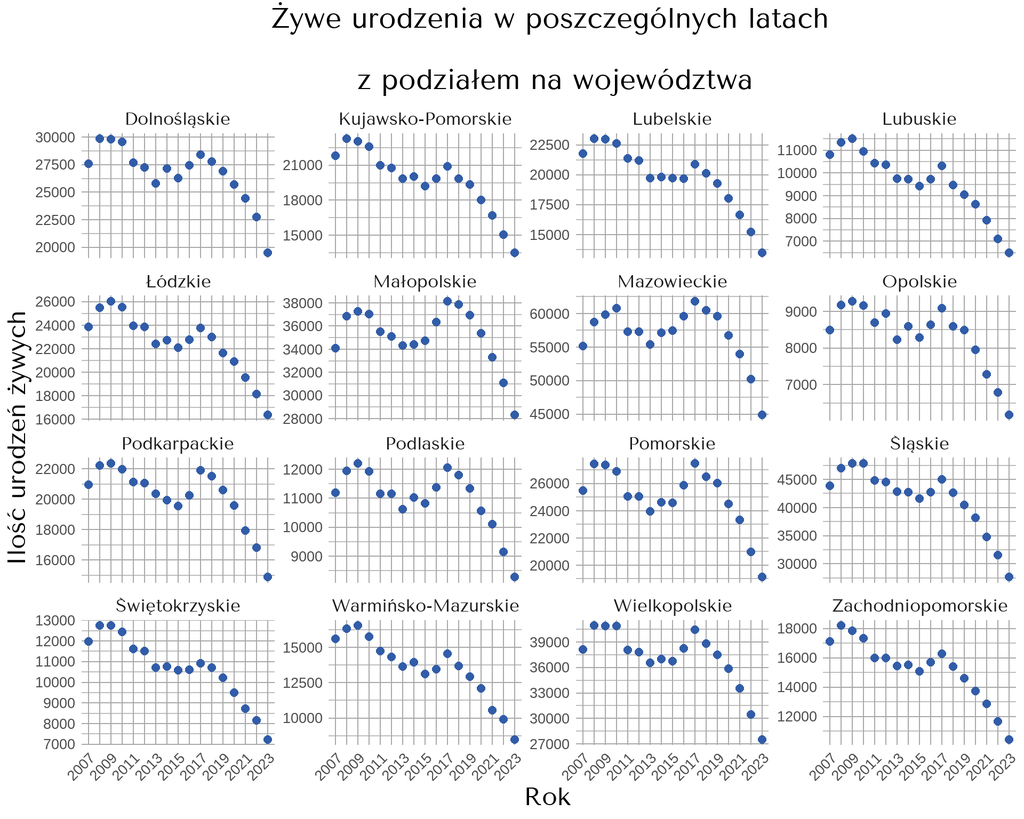

```r
bobasy %>%
  ggplot(aes(
    x = as.factor(Rok),
    y = Ilosc_zywych_urodzen,
    )
  ) +
  geom_point(color="#315ca8", size=2.5)+
  scale_x_discrete(labels= function(x) {ifelse(as.numeric(x) %% 2 == 1, x, "")}) +
  facet_wrap(~Wojewodztwo, scales = "free_y") +
  labs(
    title = "Żywe urodzenia w poszczególnych latach\n z podziałem na województwa",
    y = "Ilość urodzeń żywych",
    x = "Rok"
  ) +
  theme_minimal() +
  theme(
    strip.text = element_text(size = 25, face = "bold", family = "TenorSans"),
    title = element_text(family = "TenorSans", size = 40, hjust = 1),
    axis.text.y = element_text(size = 20),
    axis.text.x = element_text(size = 20, angle = 45, hjust = 1),
    axis.title.x = element_text(size = 35, hjust = 0.5, face = "bold"),
    axis.title.y = element_text(size = 35, hjust = 0.5, face = "bold"),
    plot.title = element_text(family = "TenorSans", size = 40, face = "bold", hjust = 0.5),
    panel.grid.major = element_line(size = 0.5, color = "darkgray"),
    panel.grid.minor = element_line(size = 0.5, color = "gray"),
        )
```

Zauważamy, że w latach 2013-2015 nastąpił spadek żywych urodzeń, by w 2017 roku poszybowac w górę. Sprawdźmy jak zmieniały się liczby opuszczonych dzieci.

## 3.2 Jak zmieniały się liczby dzieci zostawianych w szpitalach?

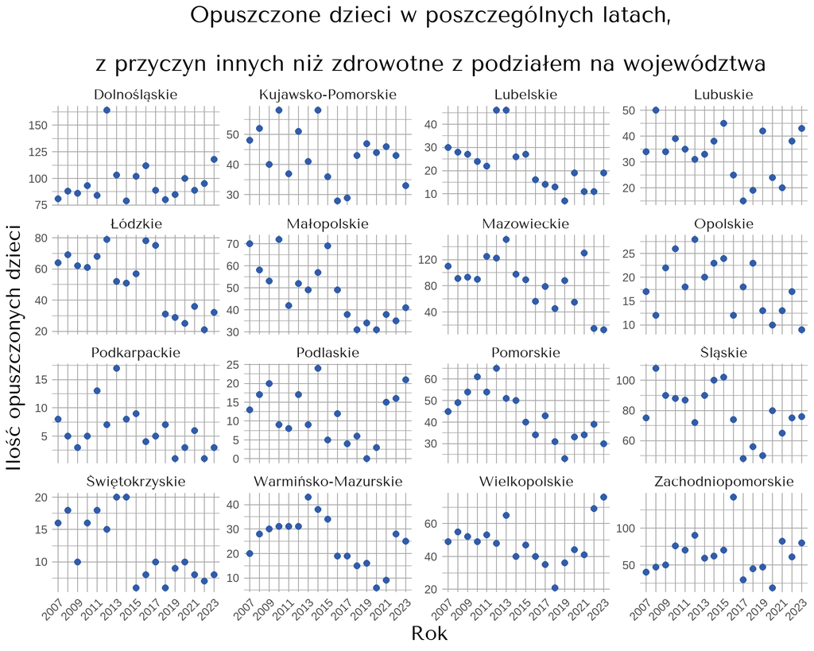

```r
bobasy %>%
  ggplot(aes(
    x = as.factor(Rok),
    y = Ilosc_pozostawionych_dzieci,
    )
  ) +
  geom_point(color="#315ca8", size=2.5)+
  scale_x_discrete(labels= function(x) {ifelse(as.numeric(x) %% 2 == 1, x, "")}) +
  facet_wrap(~Wojewodztwo, scales = "free_y") +
  labs(
    title = "Opuszczone dzieci w poszczególnych latach,\nz przyczyn innych niż zdrowotne z podziałem na województwa",
    y = "Ilość opuszczonych dzieci",
    x = "Rok"
  ) +
  theme_minimal() +
  theme(
    strip.text = element_text(size = 25, face = "bold", family = "TenorSans"),
    title = element_text(family = "TenorSans", size = 40, hjust = 1),
    axis.text.y = element_text(size = 20),
    axis.text.x = element_text(size = 20, angle = 45, hjust = 1),
    axis.title.x = element_text(size = 35, hjust = 0.5, face = "bold"),
    axis.title.y = element_text(size = 35, hjust = 0.5, face = "bold"),
    plot.title = element_text(family = "TenorSans", size = 40, face = "bold", hjust = 0.5),
    panel.grid.major = element_line(size = 0.5, color = "darkgray"),
    panel.grid.minor = element_line(size = 0.5, color = "gray"),

        )
```

W kilku województwach obserwujemy tendencję spadkową, jednak w większosi nie możemy doszukiwać się żadnej zależności. Rzućmy okiem na wartości procentowe, czyli jaki stosunek dzieci został opuszczony.

## 3.3 Badanie stosunku liczby zostawianych noworodków do liczby urodzeń

### 3.3.1 Dla poszczególnych województw

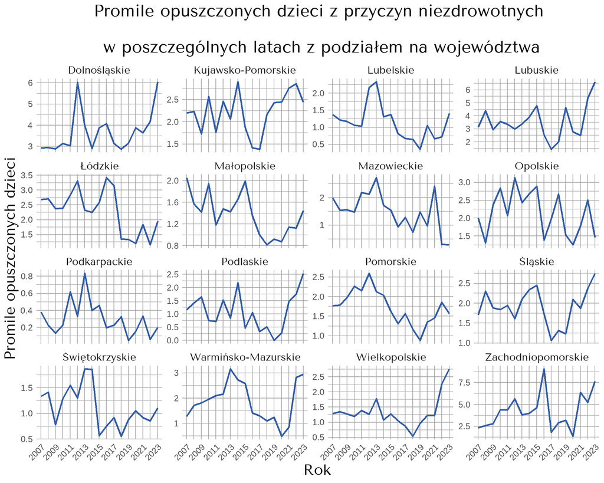

```r
bobasy %>%
  ggplot(aes(
    x = as.factor(Rok),
    y = procent_opuszczonych*1000,
    group = Wojewodztwo
    )
  ) +
  geom_line(color="#315ca8", linewidth=1)+
  scale_x_discrete(labels= function(x) {ifelse(as.numeric(x) %% 2 == 1, x, "")}) +
  facet_wrap(~Wojewodztwo, scales = "free_y") +
  labs(
    title = "Promile opuszczonych dzieci z przyczyn niezdrowotnych\n w poszczególnych latach z podziałem na województwa",
    y = "Promile opuszczonych dzieci",
    x = "Rok"
  ) +
  theme_minimal() +
  theme(
    strip.text = element_text(size = 25, face = "bold", family = "TenorSans"),
    title = element_text(family = "TenorSans", size = 40, hjust = 1),
    axis.text.y = element_text(size = 20),
    axis.text.x = element_text(size = 20, angle = 45, hjust = 1),
    axis.title.x = element_text(size = 35, hjust = 0.5, face = "bold"),
    axis.title.y = element_text(size = 35, hjust = 0.5, face = "bold"),
    plot.title = element_text(family = "TenorSans", size = 40, face = "bold", hjust = 0.5),
    panel.grid.major = element_line(size = 0.5, color = "darkgray"),
    panel.grid.minor = element_line(size = 0.5, color = "gray"),
        )
```

Okazuje się, że stosunek frakcja dzieci, które zostają opuszczane nie maleje, a nawet rośnie. Istotnie niepokojące jest to, że w roku 2023 w większości województw nastąpił wzrost. Sprawdźmy, jak sprawy się mają dla całej Polski.

### 3.3.2 Dla całej Polski

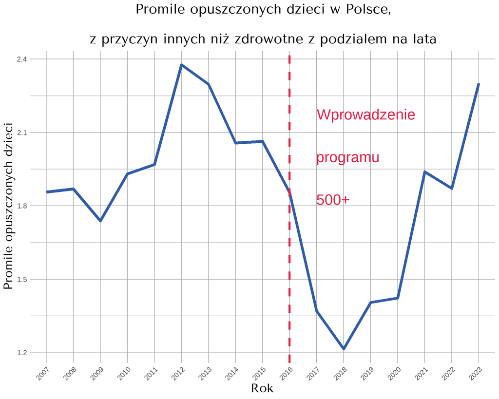

```r
bobasy %>%
  group_by(Rok) %>%
  summarise(
    suma_zostawionych = sum(Ilosc_pozostawionych_dzieci),
    suma_zywych = sum(Ilosc_zywych_urodzen)
            ) %>%
  mutate(
    procent_opuszczonych = suma_zostawionych / suma_zywych,
    nic=1
    ) %>%


  ggplot(aes(
    x = as.factor(Rok),
    y = procent_opuszczonych*1000,
    group = nic
    )
  ) +
  geom_line(color="#315ca8", linewidth=2)+
  #scale_x_discrete(labels= function(x) {ifelse(as.numeric(x) %% 2 == 1, x, "")}) +
  labs(
    title = "Promile opuszczonych dzieci w Polsce,\nz przyczyn innych niż zdrowotne z podzialem na lata",
    y = "Promile opuszczonych dzieci",
    x = "Rok"
  ) +
  theme_minimal() +
  theme(
        title = element_text(family = "TenorSans", size = 40, hjust = 1),
        axis.text.y = element_text(size = 20),
        axis.text.x = element_text(size = 20, angle = 45, hjust = 1),
        axis.title.x = element_text(size = 35, hjust = 0.5, face = "bold"),
        axis.title.y = element_text(size = 35, hjust = 0.5, face = "bold"),
        plot.title = element_text(family = "TenorSans", size = 40, face = "bold", hjust = 0.5),
        panel.grid.major = element_line(size = 0.5, color = "darkgray"),
        panel.grid.minor = element_line(size = 0.5, color = "gray")
  ) +
  geom_vline(
    xintercept = "2016", color = "#e62248",
    size = 1.5, linetype = "dashed"
    ) +
  annotate(
    "text", x = "2017", y = 2.0, label = "Wprowadzenie\nprogramu\n500+",
    hjust = 0, size = 15, color = "#e62248", face = "bold")
```

Jak widzimy problem jest realny, bo średnio 2 na 1000 dzieci zostaje opuszczone w szpitalach, a problem zdaje się przybierać na sile. Ciekawym spostrzeżeniem jest również zauważalny niż w okresie 2017-2019. Czyżby wprowadzenie 500+ w roku 2016 miało na to jakiś wpływ?

Niemniej jednak, problem jest na tyle poważny, że wymaga głębszej analizy. Sprawdźmy, czy problem dotyczy całej Polski równomiernie, czy może jest nasilony w jej niektórych regionach.

## 3.4 Sprawdzenie poszczególnych województw pod kątem odsetka zostawianych noworodków

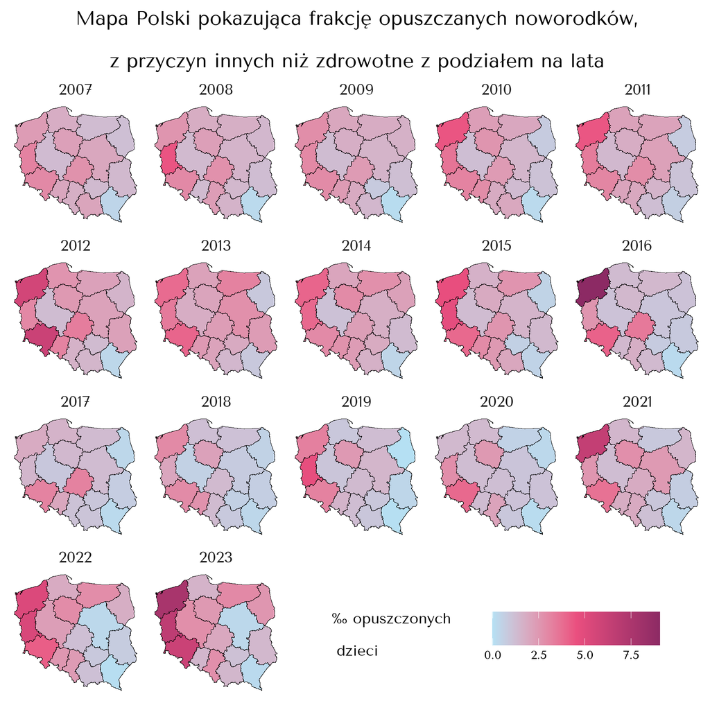

Zauważamy, że występują regiony, w których problem praktycznie nie występuje (woj. podkarpackie) oraz takie, w której problem przybiera na sile (zachodnia część Polski). Widoczna jest również znaczna poprawa sytuacji w województwie mazowieckim. Sprawdźmy również, jak prezentuję się stosunek liczby dzieci w pieczy zastępczej do wszystkich dzieci w danym województwie.

# 4. Sprawdzenie jaka część dzieci w poszczególnych województwach stanowi piecz zastępcza

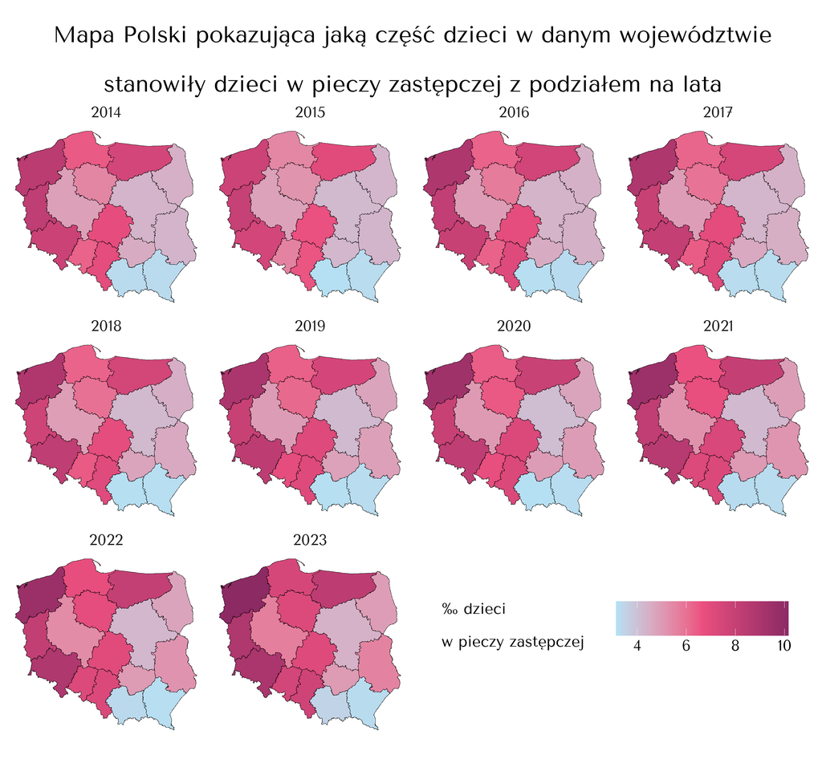

Pierwsze, co rzuca nam się w oczy to fakt, że województwa w których frakcja opuszczanych noworodków nie z przyczyn zdrowotnych była największa posiadają największy udział dzieci w pieczy zastępczej w ich całkowitej liczbie (prawie 1%). Widać również, że w ostatnich latach w województwach pomorskim oraz kujawsko-pomorskim sytuacja uległa pogorszeniu. Z drugiej strony zaskakująco pozytwne wyniki prezentują się w województwie małopolskim oraz podkarpackim.

# 5. Podsumowanie

Widzimy, że problem dzieci w pieczy zastępczej jest realny.Nie możemy jednak pominąć faktu, że inne czynniki poza noworodkami pozostawionymi w szpitalach, wpływają na frakcję młodzieży w pieczy zastępczej. Szczególnie niepokojącą sytuację obserwujemy w województwach na zachodzie naszego kraju. Może wśród danych z tamtych województw powinniśmy zacząć szukać odpowiedzi jak zapobiegać i zwalczać ten ogromny problem? Dodatkowo wiemy, gdzie problem jest mniej nasilony, co pozwala nam zbadać jakie czynniki mogą wpływać na jego zmiejszenie.